# Obesity in Scotland in relation to factors included in the Scottish Health Surveys

Author

Group 9 (2718740K Kyle Kim)

# 1 Introduction

Obesity represents a significant public health issue globally, linked to numerous chronic diseases and a major cause of premature morbidity and mortality. Scotland has the highest obesity rate in the UK in addition to having one of the highest in the developed world which clearly emphasises the significance of the problem. The Scottish health surveys from 2008 and 2012 collected data from individuals regarding their Age, Sex, Education, Body Mass Index (BMI) and whether they consumed the recommended daily fruit and vegetable intake in order to examine the prevalence and determinants of obesity in Scotland. It aims to identify trends in obesity rates over the years and explore how demographic factors, socio-economic status, and lifestyle choices such as diet impact obesity levels. Through descriptive statistics and logistic regression analysis we will be investigating whether the prevalence of obesity in Scotland changed over the given years (2008 to 2012). Additionally, whether the obesity status of individuals is effected differently in relation to their age, gender, socio-economic status or lifestyle factors. From this, we can offer evidence-based recommendations for public health strategies to mitigate this growing health concern.

# 2 Exploratory data analysis

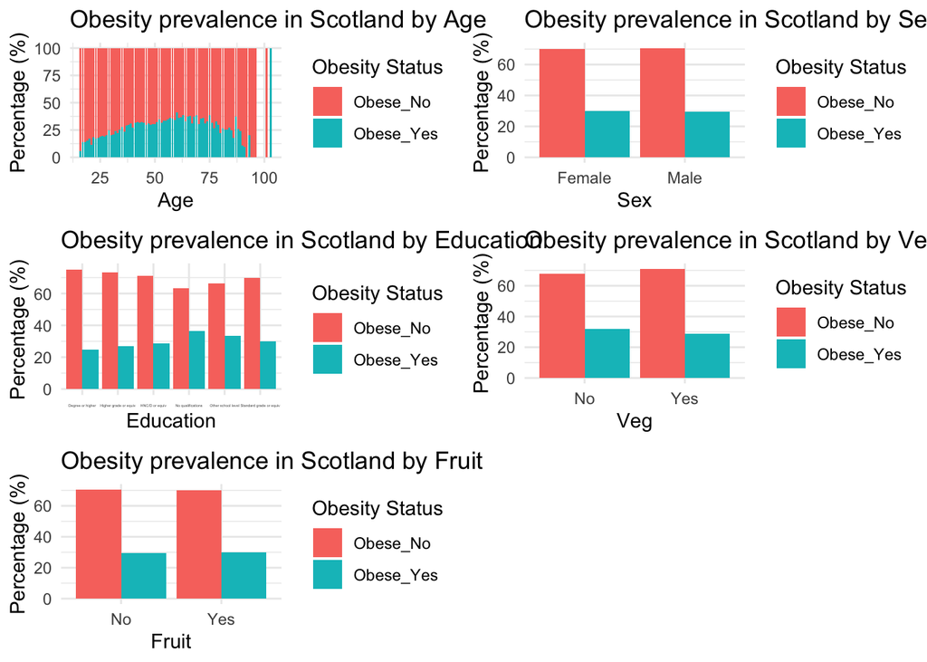

Figure 1: Scotland’s Obesity prevalence over the factors

The Figure 2 data indicates minor fluctuations in Scotland’s obesity rates from 2008 to 2012, with a notable peak at 30.47% in 2010. The graph underscores this trend, showcasing the temporary surge in 2010 against a backdrop of overall stability.

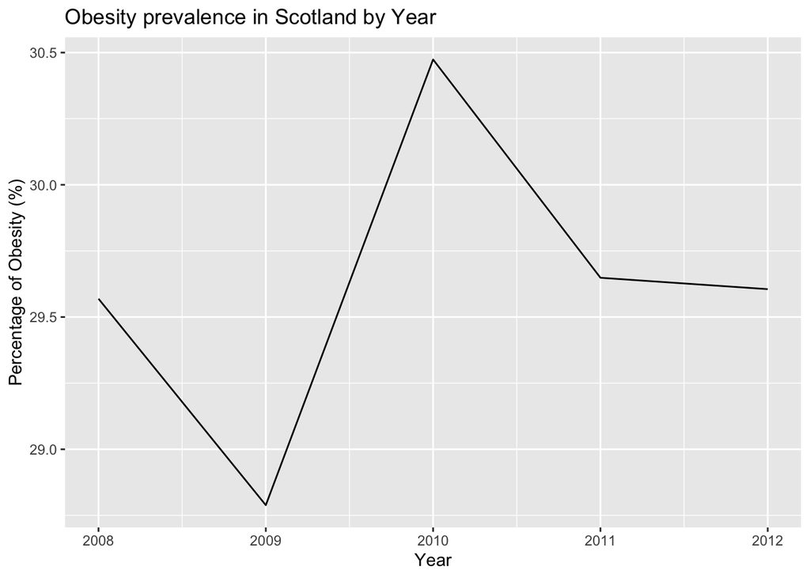

Figure 2: Percentage of obese people in Scotland by year

The Figure 1 indicate a correlation between age and obesity prevalence in Scotland, showing an increase in obesity rates with age, peaking at 35.9% among those aged 60-70. This pattern highlights this age group as having the highest obesity proportion. Beyond this peak, obesity percentages decline with further age increase, with individuals aged 90 and above exhibiting the lowest rate at 9.52%.

The Figure 1 shows a slight disparity in obesity rates between genders in Scotland, with females at 29.80659% and males slightly lower at 29.36790%. This minor difference is visually depicted in the barchart, where the female bar is marginally taller than the male bar, underscoring the small yet apparent gap. The graph illustrates that obesity is a substantial health concern for both sexes, indicating high prevalence rates across genders.

The Figure 1 display a trend where obesity rates in Scotland decrease with increasing educational levels, from the highest rate among those without qualifications (36.46659%) to the lowest in individuals with degrees or higher (24.77144%), suggesting an inverse correlation between education and obesity.

The Figure 1 illustrate a slight difference in obesity rates between fruit consumers (29.72168%) and non-consumers (29.36099%), with nearly equal bar heights in the graph. This suggests a minimal impact of fruit consumption on obesity prevalence, highlighting the complex interplay of dietary and lifestyle factors in determining obesity.

# 3 Formal data analysis

## 3.1 Prevalence of obesity from 2008 to 2012

Next, we formally analyse the data by considering each objectives in turn. Firstly, The logistic regression model for obesity prevalence from 2008 to 2012 which will be fitted is given below :

$$\ \log\left(\frac{p_i}{1-p_i}\right) = \beta_0 + \beta_1 Year(x) + \epsilon, ~~\epsilon \sim N(0, \sigma^2)\\
i~=~1,\cdot\cdot\cdot~,25224$$

where

- $p$ denotes the probability of the outcome being obese (outcome 1)
- $\beta_0$ denotes the intercept of the regression line for the baseline Year (2008)
- $\beta_1$ denotes the coefficients for the specified Year
- $\epsilon$ denotes random error component which are normally distributed with mean zero
- $\sigma^2$ denotes variance

The analysis of the data presented in Table 1 reveals that the coefficients β0 and β1 are -12.13 and 0.0056, respectively. Despite these values, the significance tests indicate that they are not statistically significant at the 5% level, with p-values of 0.5581 and 0.5865, respectively. This aligns with the preliminary observations discussed in Section 2, reinforcing the conclusion that the evidence is inadequate to suggest any significant variation in obesity prevalence in Scotland from 2008 to 2012. Thus, the initial hypothesis suggesting a change in obesity rates within the observed period is not supported by the empirical analysis.

Table 1: Estimates of the regression model coefficients (year).

| Groups | Estimates | pvalues |
| --- | --- | --- |
| Intercept | -12.1300429 | 0.5580535 |
| Year | 0.0056043 | 0.5864945 |

## 3.2 Prevalence of Obesity on the explanatory variables Age, Sex, Education and dietary habits

The model was established by including an array of independent variables such as age, sex, various educational levels, and dietary habits encompassing vegetable and fruit intake. This logistic regression model was selected due to the binary nature of the dependent variable—obesity, categorized as ‘obese_yes’ or ‘obese_no’. The model sought to express the log-odds of the probability of being obese as a linear combination of the predictors, as illustrated by the logistic function:

$$\ \log\left(\frac{p_i}{1-p_i}\right) = \beta_0 + \beta_1 Age(x_1) + \beta_2 Sex(x_2) + \beta_3 Education(x_3)\\+\beta_4Veg(x_4) + \beta_5 Fruit(x_5) + \epsilon, ~~\epsilon \sim N(0, \sigma^2)\\ i~=~1,\cdot\cdot\cdot~,25224$$

where

- $p$ denotes the probability of the outcome being obese (outcome 1)
- $\beta_0$ denotes the intercept
- $\beta_1 , \cdot\cdot\cdot,\beta_5$ denotes the coefficients of the predictor variables
- $\epsilon$ denotes random error component which are normally distributed with mean zero
- $\sigma^2$ denotes variance

Upon evaluation of the `model_factors`, `Sex (Male)` and `Fruit` consumption were found to have p-values exceeding the threshold of 0.05, indicating that they do not significantly contribute to the prediction of obesity. Consequently, these variables were removed to refine the model. The refined model coefficients were obtained and are presented in Table 2, which excludes the aforementioned insignificant factors.

To evaluate the goodness of fit for the logistic regression model, the stepwise selection procedure known as stepAIC was employed. The application of stepAIC to the logistic regression model resulted in the exclusion of variables ‘Sex’ and ‘Fruit’ intake, as their presence did not contribute to a reduction in the AIC score, suggesting that their inclusion did not improve the model’s predictive ability significantly. The final model, which excludes these variables, is considered to be more parsimonious and theoretically sound for predicting the probability of obesity in the studied population.

Table 2: Estimates of the regression model coefficients.

| Groups | Estimates | pvalues |
| --- | --- | --- |
| Intercept | -1.5562531 | 0.0000000 |
| Age | 0.0116245 | 0.0000000 |
| Education Higher | 0.1476566 | 0.0016097 |
| Education HNC/D | 0.2404329 | 0.0000036 |
| Education no | 0.3856073 | 0.0000000 |
| Education other | 0.2187677 | 0.0001871 |
| Education Standard | 0.3046388 | 0.0000000 |
| Vegetable intake | -0.1395564 | 0.0000362 |

The logistic regression equation derived from the model refinement using the stepAIC process, each independent variable’s coefficient is integral to the calculation of the log-odds of the probability, p, of an individual being obese. The logistic function is represented as follows::

$$\ \log\left(\frac{p}{1-p}\right) = -1.556 + 0.012 Age+ 0.148Education_{Higher}+0.240Education_{HNC/D}\\+0.386Education_{No}+0.219Education_{Other}+0.305Education_{Standard}-0.140Veg + \epsilon, ~~\epsilon \sim N(0, \sigma^2)$$
Further analysis and interpretation of this model should take into account the odds 95% confidence intervals for these coefficients to assess the precision of the estimates. These intervals are essential for understanding the range within which the true value of the coefficients is likely to lie, with a 95% level of confidence.

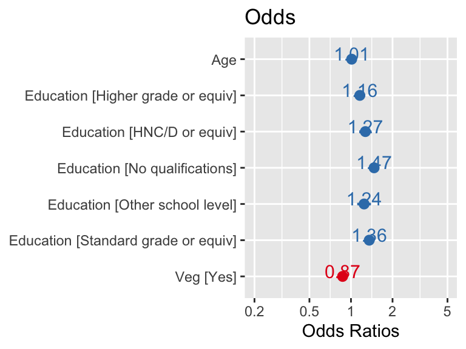

Figure 3: odds of each parameter

For the results, the model aimed to predict probabilities of obesity was developed considering various factors, including ‘Sex’ and ‘Fruit’ consumption. However, upon evaluation, both ‘Sex’ and ‘Fruit’ were identified as statistically insignificant predictors within the model. This inclusion of insignificant factors could potentially lead to inaccuracies in the predicted probabilities of obesity. Therefore, we have omitted these variables, to enhance the accuracy and reliability of the obesity probability predictions.

The shaded region around the trend line represents the confidence interval, which exhibits a slight increase in width as age progresses. This suggests a small increase in uncertainty of the predictions for the older age groups. Nonetheless, the relatively uniform width of the confidence interval across the age spectrum implies that the variance in the predicted probabilities of obesity does not drastically change with age.

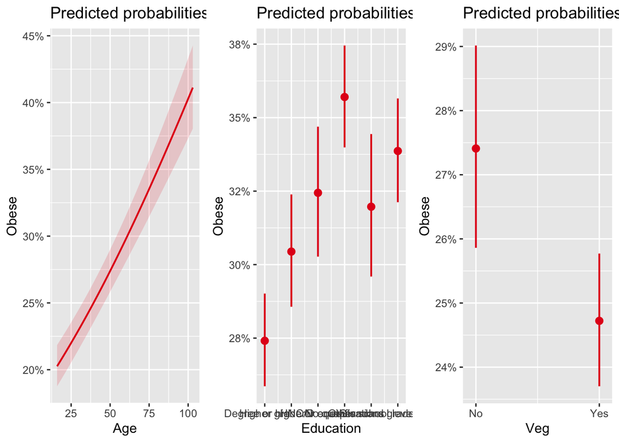

Figure 4: Predicted probabilities of obesity

Figure 4 presents a statistical analysis on the correlation between educational levels and the projected likelihood of obesity. The data suggests a distinct inverse relationship between educational attainment and the propensity for obesity. Specifically, the graph indicates that the segment of the population without any educational qualifications registers the highest mean predicted probability for obesity. In stark contrast, individuals who have obtained a degree or higher education are attributed with the lowest mean predicted probability of being classified as obese.

Additionally, an examination of the variance in the predicted probabilities reveals significant heterogeneity within the ‘Other school level’ category, which surpasses the uniformity observed in both the ‘No qualifications’ and ‘Degree or higher’ categories. This variability may suggest a complex interplay between education and other socio-economic factors that influence obesity rates. These findings highlight the importance of educational attainment in public health strategies aimed at combating obesity.

The error bars, which represent the confidence intervals, are notably longer for the ‘No’ category, implying greater uncertainty in the prediction for individuals who do not consume vegetables. The shorter error bars for the ‘Yes’ category suggest more confidence in the prediction for individuals who do consume vegetables.

This visual data suggests a potential inverse relationship between vegetable consumption and the likelihood of obesity, indicating that vegetable intake may be associated with a lower probability of being obese.

# 4 Conclusions